# What factors are coorelate to people's survival? Class, Gender or others?

## Project Summary

This is a dataset on the passengers's information in Tatinic Accident. I am intersted in understanding a simple question. What factors are related to people's survival? Were women more likely to survive? Were the wealthy more likely to survive? Did they give the youth more chance to get on the rescue boats? Below are my assumption and analysis.

## Dataset description

- Survived: Survival (0=No,1=Yes)
- passengerID
- Pclass Passenger class (Survived 1 = 1st; 2 = 2nd; 3 = 3rd)
- Name
- Sex
- Age
- sibsp: Number of Siblings/Spouses Aboard
- parch: Number of Parents/Children Aboard
- ticket: Ticket Number
- fare: Passenger Fare
- cabin: Cabin
- embarked: Port of Embarkation(C = Cherbourg; Q = Queenstown; S = Southampton)

I found the dataset very clean when I did descrptive analysis. To explore the gender factor more quickly, I decided to add an indicator "Sexindex", where it equals to 1 for female and equals to 0 for male passenger. I plot some figures to present the major variables in the dataset as follows.

```python
import pandas as pd
import numpy as np
data = pd.read_csv('~/Downloads/titanic_data.csv')

sexindex=[]
for i in data['Sex']:
    if i=='female':
        sexindex.append(1)
    elif i=='male':
        sexindex.append(0)

data['Sexindex']=sexindex
data.describe(include='all')
```

|  | PassengerId | Survived | Pclass | Name | Sex | Age | SibSp | Parch | Ticket | Fare | Cabin | Embarked | Sexindex |
| --- | --- | --- | --- | --- | --- | --- | --- | --- | --- | --- | --- | --- | --- |
| count | 891.000000 | 891.000000 | 891.000000 | 891 | 891 | 714.000000 | 891.000000 | 891.000000 | 891 | 891.000000 | 204 | 889 | 891.000000 |
| unique | NaN | NaN | NaN | 891 | 2 | NaN | NaN | NaN | 681 | NaN | 147 | 3 | NaN |
| top | NaN | NaN | NaN | Graham, Mr. George Edward | male | NaN | NaN | NaN | CA. 2343 | NaN | C23 C25 C27 | S | NaN |
| freq | NaN | NaN | NaN | 1 | 577 | NaN | NaN | NaN | 7 | NaN | 4 | 644 | NaN |
| mean | 446.000000 | 0.383838 | 2.308642 | NaN | NaN | 29.699118 | 0.523008 | 0.381594 | NaN | 32.204208 | NaN | NaN | 0.352413 |
| std | 257.353842 | 0.486592 | 0.836071 | NaN | NaN | 14.526497 | 1.102743 | 0.806057 | NaN | 49.693429 | NaN | NaN | 0.477990 |
| min | 1.000000 | 0.000000 | 1.000000 | NaN | NaN | 0.420000 | 0.000000 | 0.000000 | NaN | 0.000000 | NaN | NaN | 0.000000 |
| 25% | 223.500000 | 0.000000 | 2.000000 | NaN | NaN | 20.125000 | 0.000000 | 0.000000 | NaN | 7.910400 | NaN | NaN | 0.000000 |
| 50% | 446.000000 | 0.000000 | 3.000000 | NaN | NaN | 28.000000 | 0.000000 | 0.000000 | NaN | 14.454200 | NaN | NaN | 0.000000 |
| 75% | 668.500000 | 1.000000 | 3.000000 | NaN | NaN | 38.000000 | 1.000000 | 0.000000 | NaN | 31.000000 | NaN | NaN | 1.000000 |
| max | 891.000000 | 1.000000 | 3.000000 | NaN | NaN | 80.000000 | 8.000000 | 6.000000 | NaN | 512.329200 | NaN | NaN | 1.000000 |

As show in the table above, we can see the data is quite clean. There is no NaN value in the survived variable. The survival rate is 0.384.

The min and max value for age, SibSp, Parch and Fare is reasonable. Fare and Pclass is correlated, no surprisingly.

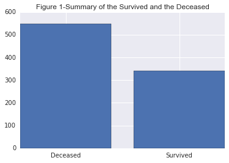

```python
import seaborn as sns
import matplotlib
%pylab inline
plt.bar([0,1],data.groupby('Survived')['PassengerId'].count(), align='center')
plt.xticks([0,1], ["Deceased","Survived"])
plt.title("Figure 1-Summary of the Survived and the Deceased")
```

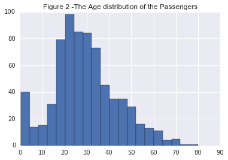

```python
data['Age'].hist(bins=20)
plt.title('Figure 2 -The Age distribution of the Passengers')
```

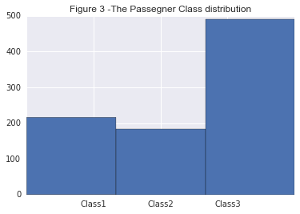

```python
%pylab inline
data['Pclass'].hist(bins=3);
plt.xticks([1,1.5,2,2.5,3], ["","Class1","Class2",'Class3', ''])
plt.title('Figure 3 -The Passegner Class distribution')
```

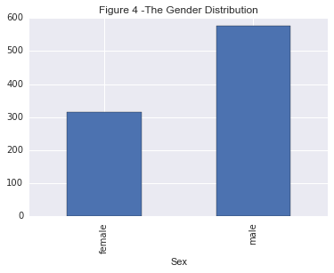

```python
%pylab inline
data.groupby('Sex')['Survived'].count().plot.bar()
plt.title('Figure 4 -The Gender Distribution')
```

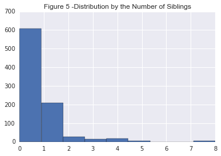

```python
%pylab inline
data['SibSp'].hist(bins=9);
plt.title('Figure 5 -Distribution by the Number of Siblings')
```

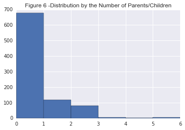

```python
data['Parch'].hist(bins=6);
plt.title('Figure 6 -Distribution by the Number of Parents/Children')
```

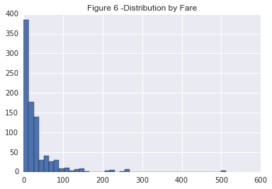

```python
data['Fare'].hist(bins=40);
plt.title('Figure 6 -Distribution by Fare')
```

```python
corrcoef(data['Pclass'],data['Fare'])
```

```
array([[ 1.        , -0.54949962],
       [-0.54949962,  1.        ]])
```

## Assumption and Research Questions

We assume gender, age and class might be related to the chance of survival. Number of Siblings/Spourses Aboard and Number of Parents/Children Aboard might be corelated to the survival rate too, as younger people and female passengers tend to have families onboard.

What's the demographics of survivals different from those who died in this tragety in terms of sex, age and class? (Who survived and who died?)

What are the top 3 factors that are related to the chance of survival? Are these factors correlated?

## Methodology:

1. We first identify the demographics differences between the survived and deceased group
2. To find the answer to the second question, we test the survival rate difference by groups due to different factors.
3. I conducted t and f test to determine whether these factors are statitstically significant
4. Using covariance analysis, top 3 factors are found.

### Step 1. Identify the demographics difference between the survived and deceased groups

We examined the dataset and decided to focus on the five factors: **Sex, Age, Pclass, Parch and SibSp**. We did not dive into the other factors either because they are strongly correlated to existing factor (such as fare and Pclass) or the data of that variable is incomplete (e.g. Carbin) or unrelated (e.g. Embarked)

Comparing the survived and deceased group among the five factors, we found the following

```
 <a list of 8 Text xticklabel objects>)
```

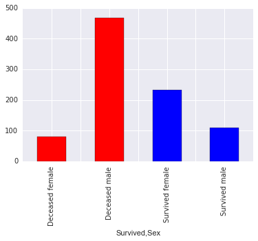

```python
data.groupby(['Survived','Sex'])['PassengerId'].count().plot.bar(color=["r","r","b","b"])
plt.xticks([0,0.5,1,1.5,2,2.5,3,3.5], ["Deceased female",'',"Deceased male","","Survived female","",'Survived male',""])
```

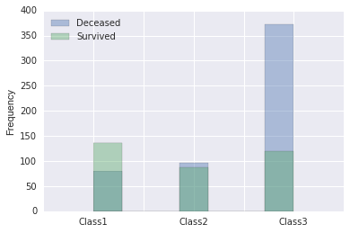

```python
data.groupby('Survived')['Pclass'].plot.hist(bins=7, alpha=0.4)
plt.xticks([0.5,1,1.5,2,2.5,3,3.5], ["","Class1","","Class2","",'Class3',""])
plt.legend(labels=['Deceased','Survived'],loc='best')
```

```python
data.groupby('Survived')['Age'].mean()
```

```
Survived
0    30.626179
1    28.343690
Name: Age, dtype: float64
```

```python
data.groupby('Survived')['Parch'].mean()
```

```
Survived
0    0.329690
1    0.464912
Name: Parch, dtype: float64
```

```python
data.groupby('Survived')['SibSp'].mean()
```

```
Survived
0    0.553734
1    0.473684
Name: SibSp, dtype: float64
```

### Step 2. Analyze survival rate difference by groups due to different factors

In this step, I analysis the survival rate difference against the key factors including Age, Sex, Pclass and Parch. I tease out the top three factors that are Sex, Pclass and Age, and test their statistical significance.

#### Sex

From our analysis, we first found female passenger are more likely to be saved. The survial rate of female is 0.742, which is much higher than that of male passengers at 0.189.

```python
data.groupby('Sex')['Survived'].mean()
```

```
Sex
female    0.742038
male      0.188908
Name: Survived, dtype: float64
```

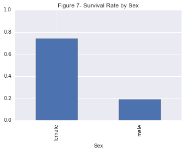

```python
data.groupby('Sex')['Survived'].mean().plot.bar()
plt.ylim(0,1)
plt.title("Figure 7- Survival Rate by Sex")
```

#### Passenger Class

As shown in Figure 8, the survival rate of different classes differs. With class one is highest, class two the second and class three the least. It is understandable as people at better class would more likely to get resource more quickly.

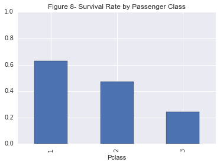

```python
data.groupby('Pclass')['Survived'].mean().plot.bar()
plt.ylim(0,1)
plt.title("Figure 8- Survival Rate by Passenger Class")
```

From the above analysis, we assume female passgener in class 1 or 2 should have largest chance to survived. Our plot below confirm this assumption, as the survival rate of these two groups are higher than 90%.

```
(0, 1)
```

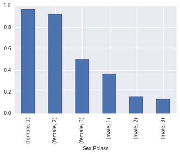

```python
data.groupby(['Sex','Pclass'])['Survived'].mean().plot.bar()
plt.ylim(0,1)
```

#### Age

As a result, to further analyze the survival rate for people younger than 16, I created a new variable 'Age_group' and set the value to 1 if Age younger than 16 and 0 otherwise. By simply calculating the mean, I found the survival rate for people younger than 16 is much higher than that of older people.

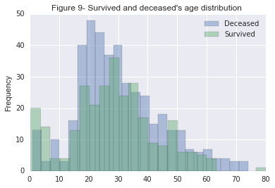

```python
data.groupby('Survived')['Age'].plot.hist(alpha=0.4, bins=24, title="Figure 9- Survived and deceased's age distribution ")
plt.legend(labels=["Deceased","Survived"])
```

```python
Age_group=[]
for i in data['Age']:
    if i <16:
        Age_group.append(1)
    else:
        Age_group.append(0)

data['Age_group']=Age_group
data.groupby('Age_group')['Survived'].count()
```

```
Age_group
0    808
1     83
Name: Survived, dtype: int64
```

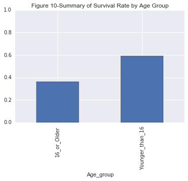

```python
data.groupby('Age_group')['Survived'].mean().plot.bar()
plt.xticks([0,1], ["16_or_Older","Younger_than_16"])
plt.ylim(0,1)
plt.title("Figure 10-Summary of Survival Rate by Age Group")
```

#### Parch Nuber of parents and children

```
(0, 1)
```

[figure not shown]

```python
Parch_group=[]
for i in data['Parch']:
    if i >1:
        Parch_group.append(1)
    else:
        Parch_group.append(0)
data['Parch_group']=Parch_group
a=data.groupby('Parch_group')['Survived'].mean().plot.bar()
plt.xticks([0,1], ["Parch=1","Parch>1"])
plt.ylim(0,1)
```

```python
corrcoef(data['Parch'],data['Age_group'])
```

```
array([[ 1.        ,  0.35148067],
       [ 0.35148067,  1.        ]])
```

#### SibSp Number of Siblings

I am not sure what effect the number of siblings will be related to the chance of survive, so I did a simple plot. I cannot see a very clear pattern from the plot.

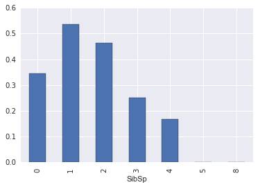

```python
data.groupby('SibSp')['Survived'].mean().plot.bar()
```

## Step 3. Testing the key factors - are they statistically significant?

#### Sex - significant

We set confidence level as 95%. Since we don't know the population mean, and the sample is normally distributed. We will use independ t test to test the following hypothesis.

The survival rate is higher if female.

```python
def calculate_t(variable):
    count=data.groupby(variable)['Survived'].count()
    mean=data.groupby(variable)['Survived'].mean()
    std=data.groupby(variable)['Survived'].std()
    t=(mean[0]-mean[1])/sqrt((std[0]/sqrt(count[0]))**2+(std[1]/sqrt(count[1]))**2)
    return t

calculate_t('Sexindex')
```

```
-18.671833177259163
```

#### Pclass - significant

Since we only have one factor Pclass on the survial rate of three group, we use one variable F-test to test the following hypothesis: The survival rate of three groups are differnet The null hypothesis is "the survaival rate among the three group is the same". The alternative hypothesis is "the survaival rate among the three group is different".

```python
M_class=data['Survived'].mean()
```

```python
data.groupby('Pclass')['PassengerId'].count()
```

[output not shown]

```python
Pclass_mean=data.groupby('Pclass')['Survived'].mean()
```

```python
Pclass_var=data.groupby('Pclass')['Survived'].var()
```

```python
SS_between=(Pclass_count[3]*(Pclass_mean[3]-M_class)**2
            +Pclass_count[1]*(Pclass_mean[1]-M_class)**2
            +Pclass_count[2]*(Pclass_mean[2]-M_class)**2)/2
SS_within=((Pclass_var[3]*Pclass_count[3])+
           (Pclass_var[2]*Pclass_count[2])+
           (Pclass_var[1]*Pclass_count[1]))/(891-3)
F_value=SS_between/SS_within
F_value
```

```
57.757545480758964
```

#### Age_group - significant

We set confidence level as 95%. Since we don't know the population mean, and the sample is normally distributed. We will use independ t test to test the following hypothesis.

The survival rate is higher if under 16.

```python
calculate_t('Age_group')
```

```
-4.0036573668800219
```

#### Parch_group - not very significant

We set confidence level as 95%. Since we don't know the population mean, and the sample is normally distributed. We will use independ t test to test the following hypothesis.

```python
calculate_t('Parch_group')
```

```
-1.6375313168577721
```

### Step 4. Identiy the top factors

we use Pandas' correlation coeffient calculation to find the corelation coefficients for the factor 'Sex', 'Pclass' and 'Age_group' are 0.543, -0.338 and 0.136. We also computed that for Parch and SibSp and found them both less than 0.1.

**Sex, Pclass and Age_group (whether under age 16) are top three factors to get rescued in Titanic accident.**

```python
corrcoef(data['Sexindex'],data['Survived'])
```

```
array([[ 1.        ,  0.54335138],
       [ 0.54335138,  1.        ]])
```

```python
corrcoef(data['Pclass'],data['Survived'])
```

```
array([[ 1.        , -0.33848104],
       [-0.33848104,  1.        ]])
```

```python
corrcoef(data['Age_group'],data['Survived'])
```

```
array([[ 1.        ,  0.13610698],
       [ 0.13610698,  1.        ]])
```

```python
corrcoef(data['Parch'],data['Survived'])
```

```
array([[ 1.        ,  0.08162941],
       [ 0.08162941,  1.        ]])
```

```python
corrcoef(data['SibSp'],data['Survived'])
```

```
array([[ 1.       , -0.0353225],
       [-0.0353225,  1.       ]])
```